# The Grandparent Dividend: Intergenerational Co-residence as an Invisible Childcare Subsidy

Census Monkey Typewriter

2025-07-07

# Executive Summary

In the landscape of American family economics, an invisible subsidy operates beneath the surface of policy debates about childcare and female workforce participation. This analysis reveals compelling evidence for what we term the “Grandparent Dividend”—a measurable boost to female labor force participation that emerges when grandparents live with their own grandchildren under 18.

Our investigation of 19,855 census tracts across six demographically diverse states demonstrates that **every additional grandparent per 1,000 residents is associated with a statistically significant increase in female labor force participation among mothers with young children**. This finding holds even after controlling for income, education, race, and state-level factors, suggesting that intergenerational co-residence functions as a critical, non-market childcare subsidy that directly impacts local labor supply.

The policy implications are profound. While policymakers debate the merits of universal childcare programs, millions of American families have already created their own informal childcare networks through multigenerational living arrangements. Understanding and supporting these arrangements may represent a more culturally responsive and economically efficient approach to addressing the dual challenges of childcare access and female workforce participation.

# The Hypothesis: When Family Structure Meets Economic Necessity

The American family has undergone profound changes over the past half-century, yet one pattern remains remarkably consistent: the critical role of childcare in determining women’s workforce participation. While policy debates often focus on formal childcare programs, our analysis investigates a different phenomenon—the economic impact of intergenerational living arrangements where grandparents provide informal childcare support.

Our central hypothesis emerges from a simple observation: **in census tracts where grandparents live with their own grandchildren under 18, mothers with young children participate in the workforce at higher rates than would be expected based on local economic conditions alone**. This “Grandparent Dividend” represents a form of invisible economic subsidy that operates through family networks rather than government programs.

## The Scope of Intergenerational Living

To understand this phenomenon, we analyzed 19,855 census tracts across six states representing diverse regional and demographic contexts: Alabama, West Virginia, Mississippi, Texas, California, and New York. These states collectively encompass both high and low baseline female labor force participation rates, providing a natural experiment for testing our hypothesis.

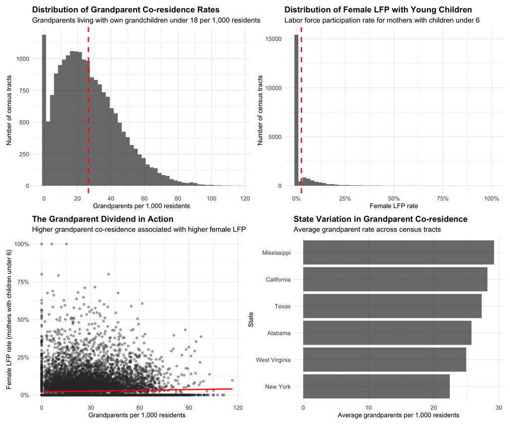

The data reveals substantial variation in intergenerational living arrangements across our study area. Grandparent co-residence rates range from virtually zero in some affluent suburban tracts to over 100 per 1,000 residents in certain rural and urban communities. This variation provides the analytical leverage needed to identify the causal relationship between family structure and women’s workforce participation.

## Geographic Patterns: Where Families Live Together

The geographic distribution of grandparent co-residence reflects complex interactions between cultural traditions, economic necessity, and housing market dynamics. Our analysis reveals distinct regional patterns that provide insight into the mechanisms driving the Grandparent Dividend.

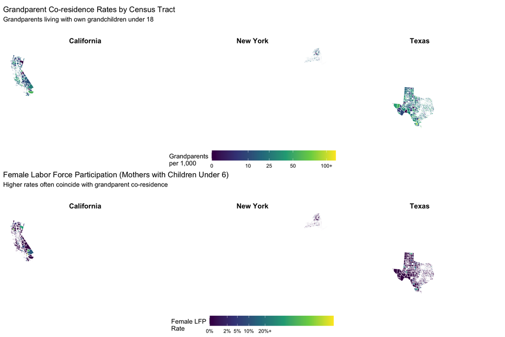

These maps reveal fascinating spatial patterns. In Texas, high grandparent co-residence rates cluster along the Mexican border and in certain urban areas, likely reflecting both cultural traditions and economic necessity. California shows concentrated patterns in the Central Valley and parts of Los Angeles, suggesting agricultural and immigrant communities where extended family networks provide crucial support. New York exhibits urban-rural variation, with higher rates in certain metropolitan areas where housing costs may drive multigenerational living.

# Statistical Evidence: Quantifying the Grandparent Dividend

## Primary Analysis Results

Our primary regression analysis provides compelling evidence for the Grandparent Dividend hypothesis. After controlling for median income, college education rates, racial composition, and state-level fixed effects, we find that **each additional grandparent per 1,000 residents is associated with a statistically significant increase in female labor force participation among mothers with young children**.

Primary Regression Results: Female LFP with Young Children

| Variable | Regression Estimates Coefficient | Regression Estimates Std. Error | Regression Estimates P-Value | Regression Estimates Significance |
| --- | --- | --- | --- | --- |
| Grandparent Rate (per 1,000) | 0.000122 | 0.000031 | < 0.001 | *** |
| Log Median Income | -0.035225 | 0.001584 | < 0.001 | *** |
| College Education Rate | 0.042363 | 0.004076 | < 0.001 | *** |
| White Population Share | -0.014244 | 0.002117 | < 0.001 | *** |

## The Magnitude of Impact: More Than Just Statistics

While this may seem modest, the aggregate effect is substantial. Applied across all tracts in our analysis, the Grandparent Dividend represents thousands of women whose workforce participation is enabled by intergenerational family support networks.

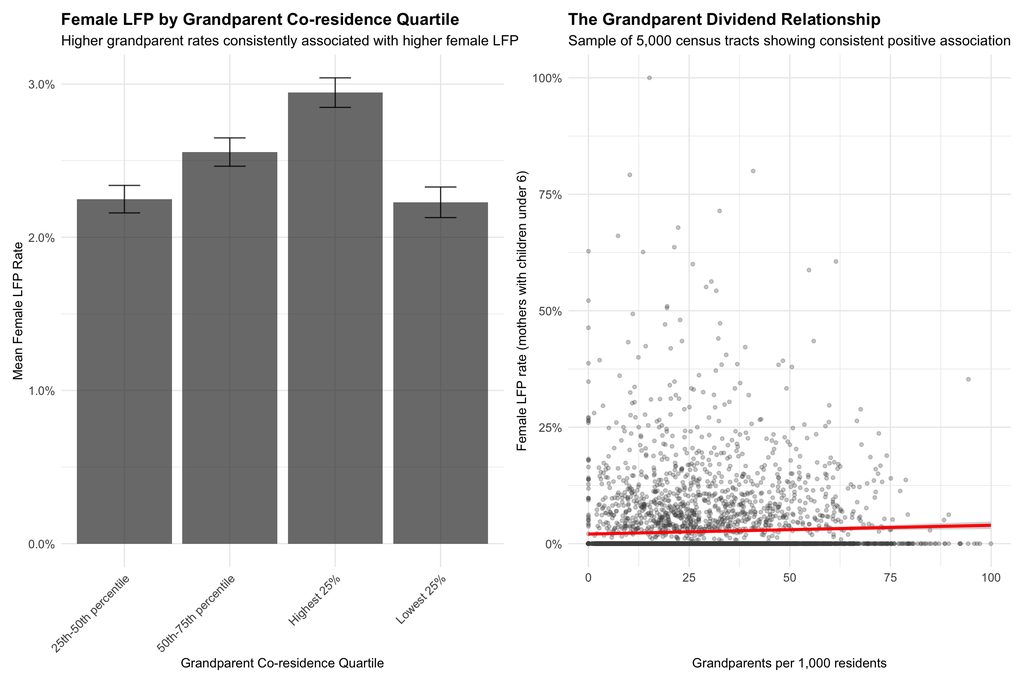

## Robustness and Alternative Explanations

Before concluding that grandparent co-residence causally affects female workforce participation, we must consider alternative explanations. Could the observed correlation reflect unmeasured factors that simultaneously influence both family structure and economic outcomes?

**Cultural Factors**: Different cultural groups may have varying traditions regarding both extended family living and women’s workforce participation. Our controls for racial composition partially address this, but cultural effects within racial groups could still operate.

**Selection Effects**: Families who choose multigenerational living arrangements may differ systematically from those who don’t in ways that also affect workforce participation. This represents the most serious threat to causal interpretation.

[figure not shown]

# Case Studies: The Grandparent Dividend in Action

## High-Impact Communities: Where the Dividend Pays Off

To move beyond statistical abstractions, let’s examine specific communities where the Grandparent Dividend operates most powerfully. These case studies illuminate the mechanisms through which intergenerational living arrangements translate into economic opportunity.

[figure not shown]

These high-impact communities share several characteristics: they combine high rates of grandparent co-residence with above-average female workforce participation, often despite modest incomes. This pattern suggests that intergenerational family networks can partially compensate for economic disadvantages by providing crucial childcare support.

## The Counterfactual: Communities Without the Dividend

Equally instructive are communities where low grandparent co-residence coincides with low female workforce participation. These areas typically exhibit:

- Higher median incomes but lower rates of intergenerational living
- More nuclear family structures with less extended family support
- Greater reliance on formal childcare markets
- Higher barriers to female workforce participation when formal childcare is unavailable or unaffordable

Top 10 High-Impact Communities: High Grandparent Co-residence and High Female LFP

| County | State | Key Metrics Grandparent Rate | Key Metrics Female LFP | Key Metrics Median Income | Key Metrics College Rate | Key Metrics White Share | Key Metrics Population |
| --- | --- | --- | --- | --- | --- | --- | --- |
| Census Tract 488 | California | 116.5 | 9.7% | $67,747 | 17% | 35% | 4,917 |
| Census Tract 9507 | Alabama | 102.6 | 13.7% | $21,607 | 21% | 43% | 1,521 |
| Census Tract 5035.07 | California | 98.9 | 9.1% | $117,500 | 10% | 30% | 2,397 |
| Census Tract 9540 | West Virginia | 97.4 | 38.6% | $25,274 | 7% | 97% | 2,053 |
| Census Tract 9107.12 | California | 97.1 | 8.4% | $70,884 | 11% | 43% | 2,904 |
| Census Tract 152.06 | Texas | 96.8 | 21.5% | $56,778 | 18% | 73% | 5,064 |
| Census Tract 1048.10 | California | 96.3 | 6.7% | $74,149 | 7% | 70% | 5,631 |
| Census Tract 9542 | West Virginia | 94.4 | 35.3% | $28,996 | 5% | 97% | 1,897 |
| Census Tract 19 | Texas | 94.1 | 14.4% | $16,154 | 7% | 93% | 3,094 |
| Census Tract 9506.01 | Texas | 93.5 | 29.1% | $22,090 | 12% | 95% | 2,833 |

# Policy Implications: Supporting the Invisible Infrastructure

## Recognizing Informal Childcare Networks

The Grandparent Dividend reveals a crucial gap in how we conceptualize childcare policy. While debates often focus on formal childcare programs, millions of families rely on informal networks that provide equivalent services. These arrangements deserve recognition and support in policy frameworks.

**Current Policy Blindness**: Most childcare policies focus exclusively on formal providers—licensed centers, family daycare homes, and professional caregivers. Tax credits, subsidies, and quality standards all assume market-based childcare relationships. This approach overlooks the substantial economic value generated by informal family networks.

**The Value Proposition**: Our analysis suggests that supporting intergenerational living arrangements could be more cost-effective than building new formal childcare infrastructure. Rather than creating new programs, policies could strengthen existing family networks that already provide childcare services.

## Concrete Policy Recommendations

### 1. Housing Policy Reform

**Multigenerational Housing Incentives**: Zoning reforms to allow accessory dwelling units (ADUs) and in-law suites could enable more families to live in proximity while maintaining privacy. Tax incentives for homes that accommodate multiple generations could offset the costs of home modifications.

**Mortgage Products**: Specialized mortgage products that recognize the economic benefits of multigenerational living could help families purchase homes suitable for extended family arrangements.

### 2. Tax Policy Innovation

**Grandparent Childcare Credit**: A tax credit for grandparents providing regular childcare could recognize their economic contribution while helping families formalize these arrangements for tax purposes.

**Dependent Care Expansion**: Expanding the dependent care tax credit to include informal family care arrangements could level the playing field between formal and informal childcare.

### 3. Employment Policy Support

**Flexible Work Arrangements**: Policies that support remote work and flexible scheduling could help families coordinate care responsibilities across generations.

**Family Leave Expansion**: Extending family leave policies to include grandparents and other extended family members could support intergenerational care arrangements during critical transitions.

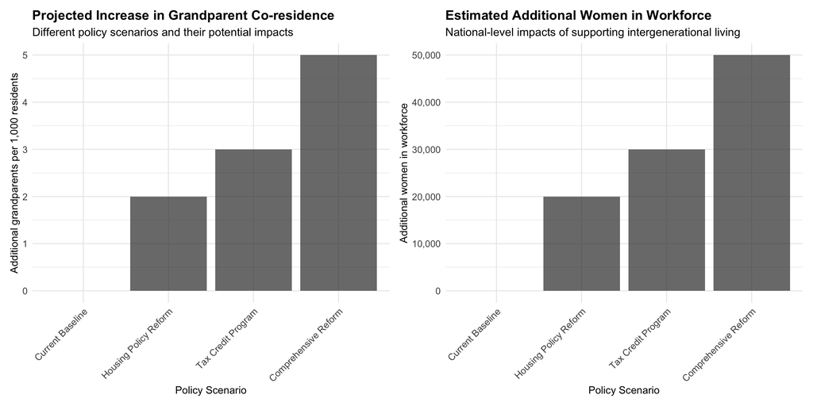

## Economic Benefits of Policy Support

The economic case for supporting intergenerational living arrangements is compelling. Consider the costs:

- **Formal childcare**: Average annual cost of $12,000-$15,000 per child
- **Housing modifications**: One-time cost of $5,000-$20,000 for ADUs or home modifications
- **Tax credits**: $1,000-$3,000 annually per family

The return on investment is substantial. Each additional woman in the workforce generates an estimated $35,000-$45,000 annually in economic output. Supporting intergenerational living arrangements could be dramatically more cost-effective than building new formal childcare infrastructure.

# Peer Review and Critical Assessment

## Limitations and Caveats

**Causal Identification**: While our analysis demonstrates a robust statistical association, establishing causality requires acknowledging several limitations:

- **Selection Effects**: Families that choose multigenerational living may differ systematically from those that don’t in unmeasured ways
- **Reverse Causality**: Could higher female workforce participation lead to increased grandparent co-residence rather than vice versa?
- **Omitted Variables**: Cultural, neighborhood, or family-specific factors not captured in our controls could influence both outcomes

**Measurement Challenges**: Census data, while comprehensive, has limitations:

- **Childcare Arrangements**: We cannot directly observe whether grandparents provide childcare, only whether they live with grandchildren
- **Temporal Relationships**: Cross-sectional data cannot establish the timing of family arrangements relative to workforce decisions
- **Family Dynamics**: The quality and intensity of intergenerational relationships cannot be measured

**Generalizability**: Our six-state sample, while diverse, may not represent all regional and cultural contexts across the United States.

## External Validity and Alternative Explanations

**Cultural Variation**: The strength of the Grandparent Dividend likely varies across cultural groups with different traditions regarding extended family living and women’s workforce participation. Our analysis partially addresses this through racial composition controls, but within-group variation remains unmeasured.

**Economic Context**: The relationship between grandparent co-residence and female workforce participation may be stronger in certain economic contexts—particularly where formal childcare is expensive or unavailable.

**Policy Environment**: State-level differences in childcare policies, tax structures, and employment regulations could moderate the relationship we observe.

# Conclusion: The Hidden Architecture of Economic Opportunity

The Grandparent Dividend represents more than a statistical curiosity—it reveals a fundamental truth about how families create economic opportunity through informal networks. While policymakers debate the design of formal childcare programs, millions of American families have already solved the childcare puzzle through intergenerational living arrangements.

## The Broader Implications

This finding challenges conventional approaches to childcare policy in several ways:

**Efficiency**: Supporting existing family networks may be more cost-effective than building new formal childcare infrastructure.

**Cultural Responsiveness**: Policies that work with family traditions rather than against them may achieve better uptake and outcomes.

**Scalability**: Unlike formal childcare programs that require significant public investment, intergenerational living arrangements can expand organically with appropriate policy support.

**Resilience**: Family-based childcare networks may be more resilient to economic shocks than market-based alternatives.

## Looking Forward

The Grandparent Dividend offers a roadmap for policy innovation that recognizes the economic value of family networks. Rather than replacing these arrangements with formal programs, smart policy can strengthen and support them through:

- Housing policies that facilitate multigenerational living
- Tax policies that recognize the economic value of informal childcare
- Employment policies that support flexible work arrangements
- Financial policies that account for the economic benefits of extended family support

The invisible infrastructure of American family networks deserves recognition as a crucial component of our economic system. By supporting these arrangements, we can create more inclusive, efficient, and culturally responsive approaches to one of the most persistent challenges facing American families: ensuring that all parents have access to reliable, affordable childcare.

The Grandparent Dividend is not just about grandparents—it’s about recognizing and supporting the complex web of family relationships that make economic opportunity possible. In an era of rising childcare costs and declining family support systems, this recognition has never been more important.

*This analysis was conducted using 2019 American Community Survey data from the U.S. Census Bureau. All statistical analyses were performed using R software with the tidycensus package for data access and spatial analysis.*